# Ingeniería Mecatrónica - Laboratorio de Robótica Industrial

### David Rozo Osorio, I.M, M.Sc.

## Práctica No. 2 - Introducción a Modelos 3D - Parte 2

- Objetivo: diseñar e implementar un robot terrestre en formato URDF
- Procedimiento:
  1. Creación de paquetes.
  2. Creación modelo 3D.
  3. Archivo Launch.
  4. Compilación del paquete.
  5. Ejecución.

### Librerías adicionales

```
$ sudo apt install ros-foxy-xacro ros-foxy-joint-state-publisher-gui
$ sudo apt install ros-foxy-gazebo-ros-pkgs
```

### Creación de un paquete (pkg)

- Crear un paquete de ROS2, desde la carpeta `src` dentro del *Workspace*:

```
~/ros2_ws_2202/src $ ros2 pkg create --build-type ament_python <ros_package_name> --dependencies <package_dependencies>
```

- Ubicado en la raíz del espacio de trabajo, dentro de la carperta `src` (`ros2_ws_2202/src`), crear un paquete llamado `modelrobot_pkg_gYY`:

```
~/ros2_ws_2202/src $ ros2 pkg create modelrobot_pkg_gYY --build-type ament_python
```

Nota: `YY` debe ser modificado con base en el número de grupo asignado para el laboratorio.

- Compilar nuevamente el *pkg*

```
$ colcon build --symlink-install
```

- Iniciar sesión de Visual Studio Code desde la carpeta `ros2_ws_2202`:

```
$ code .
```

### Información geométríca del Robot

A continuación, se presentan los valores de referencias para el robot móvil.

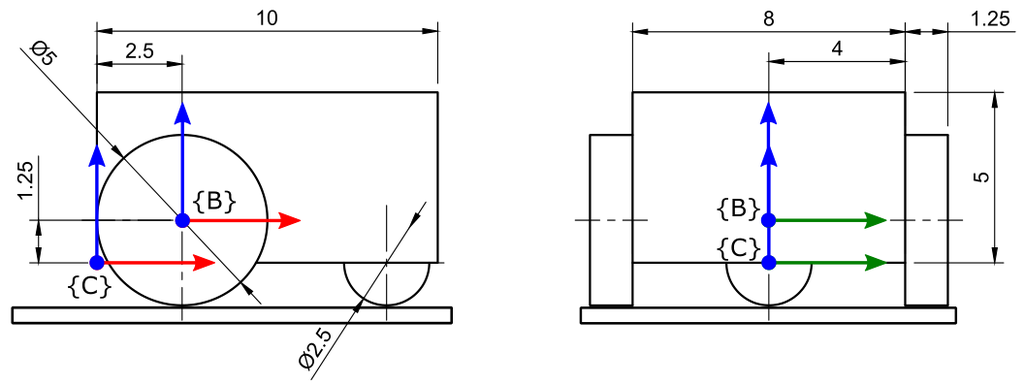

### Estructura de un Robot (Formato URDF)

- Crear una carpeta llamada `model` en la raíz del paquete `modelrobot_pkg_gYY` y crea un archivo llamado `robot_car_gYY.urdf.xacro`. El siguiente código `XML` representa la estructura básica de un robot.

```
<?xml version='1.0'?>
<robot xmlns:xacro="http://www.ros.org/wiki/xacro" name="<robot_name>">
    <link name="<link_tag>">
        <!-- ... -->
    </link>

    <joint name="<joint_tag>">
        <!-- ... -->
    </joint>

    <link name="<link_tag>">
        <!-- ... -->
    </link>
    <!-- ... -->
</robot>
```

### Definición de componentes (URDF)

- Definición URDF para un cuerpo rígido.

  ```
  <link name="<link_name>">
    <visual>
        <!-- ... -->
    </visual>

    <inertial>
        <!-- ... -->
    </inertial>

    <collision>
        <!-- ... -->
    </collision>
  </link>
  ```

- Parámetros visuales y estuctura de colisiones.

  ```
  <geometry>
    <box size="<x0 y0 z0>"/>
  </geometry>
  <origin xyz="<x0 y0 z0>" rpy="<r0 p0 y0>"/>
  ```

  ```
  <geometry>
    <cylinder radius="<d0>" length="<l0>"/>
  </geometry>
  <origin xyz="<x0 y0 z0>" rpy="<r0 p0 y0>"/>
  ```

  ```
  <geometry>
    <mesh filename="package://<pkg/meshes/file_name.stl>" scale="<s0 s1 s2>"/>
  </geometry>
  <origin xyz="<x0 y0 z0>" rpy="<r0 p0 y0>"/>
  ```

- Parámetros inerciales.

  ```
  <inertial>
    <mass value="<m0>"/>
    <origin xyz="<x0 y0 z0>" rpy="<r0 p0 y0>"/>
    <inertia ixx="<I1>" ixy="<I2>" ixz="<I3>" iyy="<I4>" iyz="<I5>" izz="<I6>"/>
  </inertial>
  ```

### Estructura general de una Articulación

- Entre 2 cuerpos rígidos siempre debe definirse una articulación. Existen diferentes *types*: `revolute`, `continuous`, `prismatic`, `fixed`, `floating`, and `planar`.

  ```
  <joint name="<joint_tag>" type="<joint_type>">
    <parent link="<link_tag1>"/>
    <child link="<link_tag2>"/>
    <origin xyz="<x0 y0 z0>" rpy="<r0 p0 y0>"/>
    <axis xyz="<i j k>"/>
    <limit effort="<e0>" lower="<l0>" upper="<u0>" velocity="<v0>"/>
    <dynamics damping="<d0>" friction="<f0>"/>
  </joint>
  ```

### Definición de Propiedades y Macros

- Una propiedad es un valor o variable que puede ser utilizado en todo el documento.

  ```
  <xacro:property name="<var_name>" value="<p0>" />
  ```

- Para utilizar la propiedad en una definición se debe emplear `"${<var_name>}"`.

  ```
  <link name="<link_tag>">
        <!-- ... -->
             <box size="${<var_name>}"/>
        <!-- ... -->
    </link>
  ```

- Una macro es una estructura rígida con parámetros que permite encapsular definiciones.

  ```
  <xacro:macro name="<macro_name>" params="<var_1 var_2 ... var_n>">
    <!-- ... -->
  </xacro:macro>
  ```

- Para utilizar la macro se inicia por el nombre de la misma y se definen todos su parámetros.

  ```
  <xacro:macro_name var_1 = "v0" var_2 = "v1" "..." var_n="vn" />
  ```

### Ejecutar Modelo Robot

- Crear un carpeta llamada `launch` en la raíz del paquete `modelrobot_pkg_gYY` y agregar un archivo con nombre `robot_launch_gYY.launch.py`.
- Un archivo `Launch` permite encapsular información de nodos y parámetros de tal forma que puedan ser ejecutados de forma secuencial a partir de un único ejecutable.

```
import os

from ament_index_python.packages import get_package_share_path

from launch import LaunchDescription
from launch_ros.actions import Node

from launch.substitutions import LaunchConfiguration
from launch.actions import DeclareLaunchArgument
from launch.conditions import IfCondition, UnlessCondition

import xacro

pkg_folder = 'modelrobot_pkg_g00'
robot_file = 'robot_car_g00.urdf.xacro'

def generate_launch_description():
    pkg_path = os.path.join(get_package_share_path(pkg_folder))
    default_model_path = os.path.join(pkg_path + '/model/' + robot_file)

    gui_arg = DeclareLaunchArgument(name='gui', default_value='true', choices=['true', 'false'], description='Flag to enable joint_state_publisher_gui')

    # Process the URDF file
    robot_description_config = xacro.process_file(default_model_path)

    params = {'robot_description': robot_description_config.toxml()}

    robot_state_publisher_node = Node(
        package='robot_state_publisher',
        executable='robot_state_publisher',
        output='screen',
        parameters=[params]
    )

    # Depending on gui parameter, either launch joint_state_publisher or joint_state_publisher_gui
    joint_state_publisher_node = Node(
        package='joint_state_publisher',
        executable='joint_state_publisher',
        condition=UnlessCondition(LaunchConfiguration('gui'))
    )

    joint_state_publisher_gui_node = Node(
        package='joint_state_publisher_gui',
        executable='joint_state_publisher_gui',
        name="joint_state_publisher_gui",
        condition=IfCondition(LaunchConfiguration('gui'))
    )

    # Launch!
    return LaunchDescription([
        gui_arg,
        joint_state_publisher_node,
        joint_state_publisher_gui_node,
        robot_state_publisher_node,
    ])
```

### Configuración del Paquete

Abrir el archivo `package.xml` que se encuentra en el paquete. Agregar la siguiente línea:

```
<license>TODO: License declaration</license> <!--add below -->
...
<exec_depend>ros2launch</exec_depend>
...
<test_depend>ament_copyright</test_depend> <!--add before -->
```

Abrir el archivo `setup.py` que se encuentra en el paquete.

- Agregar la siguiente línea en la sección de librerías:

```
from glob import glob
import os
```

- Agregar las siguientes líneas en la función `setup` parámetro `data_files`:

```
data_files=[
        ...,
        (os.path.join("share", package_name,'launch'), glob("launch/*.launch.py")),
        (os.path.join("share", package_name,'model'), glob("model/*.*")),
    ],
```

Esta última línea garantiza que cuando se compile el paquete, los archivos `*.launch.py` y cualquier archivo ubicado en la carpeta `model` sean copiados a la carpeta `install` y estén visibles para su ejecución por terminal.

### Verificación de aplicación:

1. Compilar el paquete dentro del *Workspace*.

```
~/ros2_ws_202202  $ colcon build --symlink-install
~/ros2_ws_202202  $ source ~/.bashrc
```

1. Terminal No. 1 - Ejecutar el archivo `Launch`

```
$ ros2 launch <pkg_name> <launch_file.launch.py>
```

```
$ ros2 launch modelrobot_pkg_gYY robot_launch_gYY.launch.py
```

1. Terminal No. 2 - Ejecutar el programa RViz

```
$ rviz2
```

### Ejecutar RViz desde un archivo Launch con parámetros

- Crear un carpeta llamada `launch` en la raíz del paquete `modelrobot_pkg_gYY` y agregar un archivo con nombre `simulator_gYY.launch.py`.

```
import os

from ament_index_python.packages import get_package_share_path

from launch import LaunchDescription
from launch_ros.actions import Node

from launch.substitutions import LaunchConfiguration
from launch.actions import DeclareLaunchArgument


pkg_folder = 'modelrobot_pkg_g00'
rviz_file = 'rviz_config.rviz'

def generate_launch_description():
    pkg_path = os.path.join(get_package_share_path(pkg_folder))
    default_rviz_config_path = os.path.join(pkg_path + '/model/' + rviz_file)

    rviz_arg = DeclareLaunchArgument(name='rvizconfig', default_value=str(default_rviz_config_path), description='Absolute path to rviz config file')


    # Depending on gui parameter, either launch joint_state_publisher or joint_state_publisher_gui
    rviz_node = Node(
        package='rviz2',
        executable='rviz2',
        name='rviz2',
        output='screen',
        arguments=['-d', LaunchConfiguration('rvizconfig')],
    )

    # Launch!
    return LaunchDescription([
        rviz_arg,
        rviz_node,
    ])
```

### Verificación de aplicación:

1. Compilar el paquete dentro del *Workspace*.

```
~/ros2_ws_202202  $ colcon build --symlink-install
~/ros2_ws_202202  $ source ~/.bashrc
```

1. Terminal No. 1 - Ejecutar el archivo `Launch`

```
$ ros2 launch <pkg_name> <launch_file.launch.py>
```

```
$ ros2 launch modelrobot_pkg_gYY robot_launch_gYY.launch.py
```

1. Terminal No. 2 - Ejecutar el programa RViz

[output not shown]

## Referencias

- Understanding ROS Nodes: https://docs.ros.org/en/foxy/Tutorials/Beginner-CLI-Tools/Understanding-ROS2-Nodes/Understanding-ROS2-Nodes.html
- Understanding ROS Topics: https://docs.ros.org/en/foxy/Tutorials/Beginner-CLI-Tools/Understanding-ROS2-Topics/Understanding-ROS2-Topics.html
- URDF: https://docs.ros.org/en/foxy/Tutorials/Intermediate/URDF/URDF-Main.html
- XACRO: https://docs.ros.org/en/foxy/Tutorials/Intermediate/URDF/Using-Xacro-to-Clean-Up-a-URDF-File.html
- Lentin Joseph, Robot Operating System (ROS) for Absolute Beginners, Apress. 2018.
- Ramkumar Gandhinathan, Lentin Joseph, ROS Robotics Projects, 2ed, Packt, 2019.
- Morgan Quigley, Brian Gerkey, and William D. Smart., Programming Robots with ROS, O’ Reilly Media, Inc., 2016.